# Context data: basin-scale climate indices and independent OC-CCI chlorophyll

This notebook assembles two context datasets. (1) Monthly climate indices (ENSO, PDO, NPGO, NAO, AMO) fetched from their authoritative public sources. (2) An independent chlorophyll product, ESA Ocean Colour Climate Change Initiative (OC-CCI), averaged over each sanctuary and compared with the Copernicus-GlobColour chlorophyll used in the state variables. Everything is cached; re-rendering works offline.

```r
librarian::shelf(
  dplyr, ggplot2, glue, here, httr2, knitr, lubridate, purrr, readr, sf, stringr,
  terra, tibble, tidyr, zoo, quiet = T)
options(readr.show_col_types = F)
sf_use_s2(TRUE)

# paths ----
dir_ctx     <- here("data/context")
dir_raw     <- here("data/context/raw")
dir_occci   <- here("data/context/occci")
dir_nc      <- here("data/raw/occci")          # git-ignored netcdf
dir_fig     <- here("figures/context")
idx_csv     <- file.path(dir_ctx, "indices_monthly.csv")
src_csv     <- file.path(dir_ctx, "indices_sources.csv")
occci_csv   <- file.path(dir_ctx, "chl_occci_monthly.csv")
cmp_csv     <- file.path(dir_ctx, "chl_product_compare.csv")
state_csv   <- here("data/state/state_monthly.csv")
geo_geojson <- here("data/sanctuaries.geojson")
for (d in c(dir_ctx, dir_raw, dir_occci, dir_nc, dir_fig))
  dir.create(d, showWarnings = F, recursive = T)

# constants ----
ERDDAP      <- "https://coastwatch.pfeg.noaa.gov/erddap/griddap"
OCCCI_ID    <- "pmlEsaCCI60OceanColorMonthly"
ETOPO_ID    <- "ETOPO_2022_v1_15s"
MIN_DEPTH   <- 30     # m
MIN_CELLS   <- 10
BUFFER_M    <- 10000
BUFFERED    <- c("MNMS", "GRNMS", "FGBNMS")
NMS_ORD     <- c(
  "OCNMS", "GFNMS", "CBNMS", "MBNMS", "CPNMS", "CINMS", "PNMS", "HIHWNMS", "NMSAS",
  "FGBNMS", "FKNMS", "GRNMS", "MNMS", "SBNMS")
BASE        <- c("2003-01-01", "2012-12-01")
RECENT      <- c("2016-01-01", "2025-12-01")

PAL <- list(
  surface = "#fcfcfb", ink = "#0b0b0b", ink2 = "#52514e", muted = "#898781",
  grid    = "#e1e0d9", axis = "#c3c2b7", blue = "#2a78d6", orange = "#eb6834")
theme_chk <- function(base_size = 10) {
  theme_minimal(base_size = base_size) +
    theme(
      plot.background     = element_rect(fill = PAL$surface, color = NA),
      panel.background    = element_rect(fill = PAL$surface, color = NA),
      panel.grid.major    = element_line(color = PAL$grid, linewidth = 0.25),
      panel.grid.minor    = element_blank(),
      axis.text           = element_text(color = PAL$muted),
      axis.title          = element_text(color = PAL$ink2),
      plot.title          = element_text(color = PAL$ink, face = "bold", size = rel(1.1)),
      plot.subtitle       = element_text(color = PAL$ink2),
      plot.caption        = element_text(color = PAL$muted, hjust = 0),
      plot.title.position = "plot",
      strip.text          = element_text(color = PAL$ink, face = "bold", hjust = 0),
      legend.position     = "top",
      legend.justification = "left",
      legend.title        = element_text(color = PAL$ink2),
      legend.text         = element_text(color = PAL$ink2))
}
save_fig <- function(p, name, width = 9, height = 5) {
  ggsave(file.path(dir_fig, name), p, width = width, height = height, dpi = 200, bg = PAL$surface)
  p
}
```

## Part 1. Climate indices

```r
# source table: one row per index ----
SRC <- tribble(
  ~index,  ~long_name,                                  ~url,
  "oni",   "Oceanic Nino Index (3-month mean Nino 3.4 SST anomaly)",
           "https://www.cpc.ncep.noaa.gov/data/indices/oni.ascii.txt",
  "nino34", "Nino 3.4 monthly SST anomaly (HadISST, 1981-2010 base)",
           "https://psl.noaa.gov/data/timeseries/month/data/nino34.long.anom.data",
  "pdo",   "Pacific Decadal Oscillation (ERSST v5)",
           "https://www.ncei.noaa.gov/pub/data/cmb/ersst/v5/index/ersst.v5.pdo.dat",
  "npgo",  "North Pacific Gyre Oscillation",
           "https://www.o3d.org/npgo/data/NPGO.txt",
  "nao",   "North Atlantic Oscillation (CPC)",
           "https://www.cpc.ncep.noaa.gov/products/precip/CWlink/pna/norm.nao.monthly.b5001.current.ascii.table",
  "amo",   "Atlantic Multidecadal Oscillation (ERSST v5 North Atlantic 0-60N SSTA, linearly detrended)",
           "https://www.ncei.noaa.gov/pub/data/cmb/ersst/v5/index/ersst.v5.amo.dat",
  "natl_sst", "North Atlantic 0-60N SST anomaly, ERSST v5 (not detrended)",
           "https://www.ncei.noaa.gov/pub/data/cmb/ersst/v5/index/ersst.v5.amo.dat")
NOTE <- c(
  oni    = "3-month running mean stamped on the centre month (DJF = Jan)",
  nino34 = "unsmoothed monthly anomaly; -99.99 = NA",
  pdo    = "99.99 = NA (months not yet computed)",
  npgo   = "values since 2005 from AVISO satellite SSHa; provisional",
  nao    = "CPC standardized monthly index, 1950 base",
  amo    = paste(
    "NCEI ERSST v5 North Atlantic SSTA minus its 1854-latest linear trend (Enfield et al. 2001);",
    "replaces the PSL Kaplan series, which ends in early 2023"),
  natl_sst = "undetrended source series for amo")

# download once, keep raw text, record retrieval date ----
ret_csv <- file.path(dir_raw, "retrieved.csv")
ret <- if (file.exists(ret_csv)) read_csv(ret_csv) else tibble(index = character(), retrieved = character())
for (i in seq_len(nrow(SRC))) {
  f <- file.path(dir_raw, glue("{if (SRC$index[i] == 'natl_sst') 'amo' else SRC$index[i]}.txt"))
  if (!file.exists(f)) {
    request(SRC$url[i]) |> req_retry(max_tries = 3) |> req_perform(path = f)
    ret <- bind_rows(filter(ret, index != SRC$index[i]),
                     tibble(index = SRC$index[i], retrieved = as.character(Sys.Date())))
    Sys.sleep(1)
  }
}
ret <- bind_rows(filter(ret, index != "natl_sst"), mutate(filter(ret, index == "amo"), index = "natl_sst"))
write_csv(ret, ret_csv)
```

```r
rd <- function(idx) read_lines(file.path(dir_raw, glue("{idx}.txt")))
na_if_code <- function(x, codes) replace(x, x %in% codes | x <= -99, NA_real_)

# wide year x 12-month rows (pdo, nao, nino34) ----
parse_wide <- function(idx, na_codes = c(99.99, -99.99, -99.9)) {
  rd(idx) |>
    str_trim() |>
    keep(\(l) str_detect(l, "^[0-9]{4}( +-?[0-9.]+){1,12}$")) |>
    map_dfr(\(l) {
      v <- as.numeric(str_split_1(l, " +"))
      tibble(year = v[1], month = seq_along(v[-1]), value = v[-1])
    }) |>
    mutate(
      date  = make_date(year, month, 1),
      index = idx,
      value = na_if_code(value, na_codes)) |>
    select(date, index, value)
}

oni <- rd("oni") |>
  str_trim() |>
  keep(\(l) str_detect(l, "^[A-Z]{3} [0-9]{4} ")) |>
  map_dfr(\(l) {
    p <- str_split_1(l, " +")
    tibble(seas = p[1], year = as.numeric(p[2]), value = as.numeric(p[4]))
  }) |>
  mutate(
    month = match(seas, c("DJF","JFM","FMA","MAM","AMJ","MJJ","JJA","JAS","ASO","SON","OND","NDJ")),
    date  = make_date(year, month, 1),
    index = "oni") |>
  select(date, index, value)
# centre month of DJF is January of the stated year: month = position in the list

npgo <- rd("npgo") |>
  str_trim() |>
  keep(\(l) !str_starts(l, "#") & nchar(l) > 0) |>
  map_dfr(\(l) {
    v <- as.numeric(str_split_1(l, " +"))
    tibble(date = make_date(v[1], v[2], 1), index = "npgo", value = v[3])
  })

amo <- rd("amo") |>
  str_trim() |>
  keep(\(l) str_detect(l, "^[0-9]{4} +[0-9]{1,2} +-?[0-9.]+$")) |>
  map_dfr(\(l) {
    v <- as.numeric(str_split_1(l, " +"))
    tibble(date = make_date(v[1], v[2], 1), index = "natl_sst", value = na_if_code(v[3], 99.99))
  })

# amo: linear trend over the full record (1854 to latest) removed (Enfield et al. 2001)
amo <- amo |>
  filter(!is.na(value)) |>
  mutate(
    t     = as.numeric(date),
    value = value - fitted(lm(value ~ t)),
    index = "amo") |>
  select(date, index, value) |>
  bind_rows(amo)

idx <- bind_rows(
  oni, parse_wide("nino34"), parse_wide("pdo"), npgo, parse_wide("nao"), amo) |>
  filter(date >= as.Date("1990-01-01")) |>
  arrange(match(index, SRC$index), date)

# drop trailing NA months so "last" means last month with data
idx <- idx |> filter(!is.na(value))
write_csv(idx, idx_csv)

src <- SRC |>
  left_join(ret, by = "index") |>
  left_join(
    idx |> summarize(first = min(date), last = max(date), .by = index), by = "index") |>
  mutate(note = NOTE[index]) |>
  select(index, long_name, url, retrieved, first, last, note)
write_csv(src, src_csv)
```

### Sources and coverage

```r
src |>
  mutate(first = format(first, "%Y-%m"), last = format(last, "%Y-%m")) |>
  select(index, long_name, retrieved, first, last, note) |>
  kable()
```

Table 1

| index | long_name | retrieved | first | last | note |
| --- | --- | --- | --- | --- | --- |
| oni | Oceanic Nino Index (3-month mean Nino 3.4 SST anomaly) | 2026-10-03 | 1990-01 | 2026-07 | 3-month running mean stamped on the centre month (DJF = Jan) |
| nino34 | Nino 3.4 monthly SST anomaly (HadISST, 1981-2010 base) | 2026-10-03 | 1990-01 | 2026-07 | unsmoothed monthly anomaly; -99.99 = NA |
| pdo | Pacific Decadal Oscillation (ERSST v5) | 2026-10-03 | 1990-01 | 2026-08 | 99.99 = NA (months not yet computed) |
| npgo | North Pacific Gyre Oscillation | 2026-10-03 | 1990-01 | 2026-09 | values since 2005 from AVISO satellite SSHa; provisional |
| nao | North Atlantic Oscillation (CPC) | 2026-10-03 | 1990-01 | 2026-08 | CPC standardized monthly index, 1950 base |
| amo | Atlantic Multidecadal Oscillation (ERSST v5 North Atlantic 0-60N SSTA, linearly detrended) | 2026-10-03 | 1990-01 | 2026-08 | NCEI ERSST v5 North Atlantic SSTA minus its 1854-latest linear trend (Enfield et al. 2001); replaces the PSL Kaplan series, which ends in early 2023 |
| natl_sst | North Atlantic 0-60N SST anomaly, ERSST v5 (not detrended) | 2026-10-03 | 1990-01 | 2026-08 | undetrended source series for amo |

The `amo` index is the ERSST v5 North Atlantic (0-60N) SST anomaly with its linear trend over the full record (1854 to latest) removed, following Enfield et al. (2001); a linear detrend leaves some of the recent non-linear warming in the index. The undetrended series is kept as `natl_sst`.

Full URLs are in `data/context/indices_sources.csv`. Raw text files are kept in `data/context/raw/`.

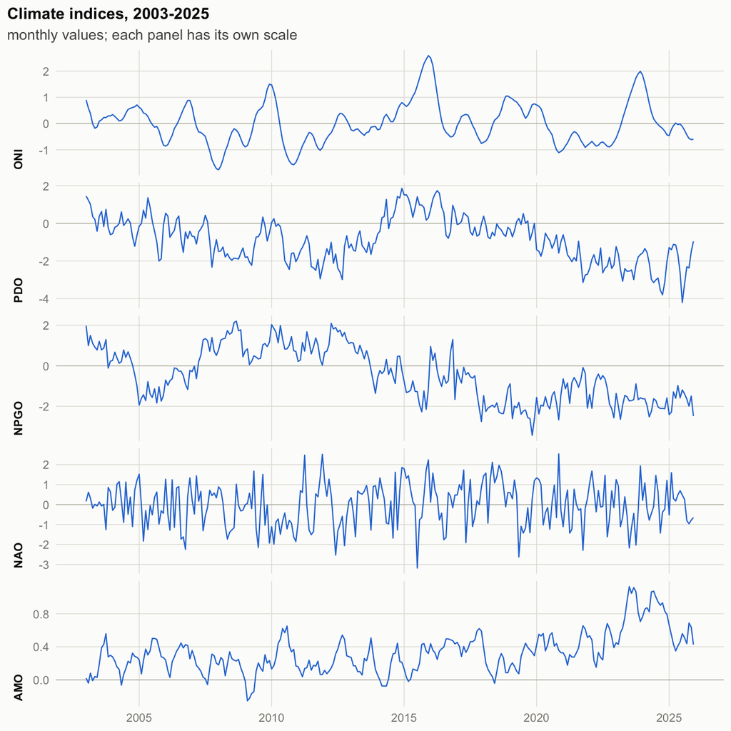

Figure 1

```r
p_idx <- idx |>
  filter(index %in% c("oni", "pdo", "npgo", "nao", "amo"), between(date, as.Date("2003-01-01"), as.Date("2025-12-01"))) |>
  mutate(index = factor(toupper(index), toupper(c("oni", "pdo", "npgo", "nao", "amo")))) |>
  ggplot(aes(date, value)) +
  geom_hline(yintercept = 0, color = PAL$axis, linewidth = 0.3) +
  geom_line(color = PAL$blue, linewidth = 0.4) +
  facet_wrap(~index, ncol = 1, scales = "free_y", strip.position = "left") +
  labs(x = NULL, y = NULL, title = "Climate indices, 2003-2025",
       subtitle = "monthly values; each panel has its own scale") +
  theme_chk() + theme(strip.placement = "outside")
save_fig(p_idx, "indices_2003-2025.png", 9, 7)
```

## Part 2. OC-CCI chlorophyll per sanctuary

Source: ESA OC-CCI v6.0 monthly chlorophyll-a (`chlor_a`, about 4 km) served as `pmlEsaCCI60OceanColorMonthly` by NOAA CoastWatch ERDDAP. Pixels whose centres fall inside the sanctuary polygon are used (Monitor, Gray’s Reef and Flower Garden Banks: polygon buffered by 10 km because the polygons are smaller than a pixel or a few pixels). `chl_occci_all` is the arithmetic mean of all pixels. `chl_occci` is the spatial geometric mean (mean of log10, back-transformed) of pixels at least 30 m deep (ETOPO 2022 15 arc-second relief, averaged to the pixel grid); with fewer than 10 such pixels all pixels are used and the `rule` says so.

```r
nms_sf <- st_read(geo_geojson, quiet = T) |>
  filter(nms %in% setdiff(NMS_ORD, "PNMS")) |>
  st_make_valid() |>
  group_by(nms) |>
  summarize(geometry = st_union(geometry), .groups = "drop")
stopifnot(setequal(nms_sf$nms, setdiff(NMS_ORD, "PNMS")))

poly_for <- function(code) {
  g <- nms_sf |> filter(nms == code) |> st_geometry()
  if (code %in% BUFFERED) g <- st_buffer(g, BUFFER_M)
  g
}

# five-year chunks; last chunk ends at the latest available month
CHUNKS <- tibble(
  y0 = seq(1997, 2022, by = 5)) |>
  mutate(
    t0 = if_else(y0 == 1997, "1997-09-01", glue("{y0}-01-01")),
    t1 = if_else(y0 == 2022, "last", glue("{y0 + 4}-12-01")))

get_nc <- function(url, f) {
  if (file.exists(f)) return(invisible(f))
  request(url) |> req_retry(max_tries = 5, backoff = \(i) 5 * i) |>
    req_timeout(300) |> req_perform(path = f)
  Sys.sleep(1)
  invisible(f)
}

occci_nms <- function(code) {
  out_csv <- file.path(dir_occci, glue("{code}.csv"))
  if (file.exists(out_csv)) return(read_csv(out_csv))
  g  <- poly_for(code)
  bb <- st_bbox(g)
  pad <- 0.05
  la <- c(bb["ymin"] - pad, bb["ymax"] + pad)
  lo <- c(bb["xmin"] - pad, bb["xmax"] + pad)
  # chlorophyll chunks
  fs <- pmap_chr(CHUNKS, \(y0, t0, t1) {
    f <- file.path(dir_nc, glue("{code}_{y0}.nc"))
    u <- glue("{ERDDAP}/{OCCCI_ID}.nc?chlor_a[({t0}):1:{if (t1 == 'last') '(last)' else glue('({t1})')}]",
              "[({la[1]}):1:({la[2]})][({lo[1]}):1:({lo[2]})]")
    get_nc(u, f)
    f
  })
  ef <- file.path(dir_nc, glue("etopo_{code}.nc"))
  get_nc(glue("{ERDDAP}/{ETOPO_ID}.nc?z[({la[1]}):2:({la[2]})][({lo[1]}):2:({lo[2]})]"), ef)

  rs   <- map(fs, \(f) rast(f, subds = "chlor_a"))
  tmpl <- rs[[1]][[1]]
  # pixel centres inside the polygon
  inside <- rasterize(vect(g), tmpl, field = 1, touches = FALSE) |> values() |> as.vector() |> is.finite()
  z      <- resample(rast(ef), tmpl, method = "average") |> values() |> as.vector()
  deep   <- inside & !is.na(z) & z <= -MIN_DEPTH
  use_deep <- sum(deep) >= MIN_CELLS
  sel_deep <- if (use_deep) deep else inside
  rule <- if (use_deep) glue("depth >= {MIN_DEPTH} m") else glue("all pixels (<{MIN_CELLS} pixels deeper than {MIN_DEPTH} m)")

  map_dfr(rs, \(r) {
    m <- values(r)
    m[!is.finite(m) | m <= 0] <- NA
    tibble(
      date          = as.Date(time(r)) |> floor_date("month"),
      chl_occci_all = apply(m[inside, , drop = F], 2, \(x) if (all(is.na(x))) NA_real_ else mean(x, na.rm = T)),
      n_cells_all   = colSums(!is.na(m[inside, , drop = F])),
      chl_occci     = apply(m[sel_deep, , drop = F], 2, \(x) if (all(is.na(x))) NA_real_ else 10^mean(log10(x), na.rm = T)),
      n_cells       = colSums(!is.na(m[sel_deep, , drop = F])),
      rule          = as.character(rule),
      n_inside      = sum(inside),
      n_deep        = sum(deep))
  }) |>
    mutate(nms = code) |>
    select(nms, date, chl_occci, chl_occci_all, n_cells, n_cells_all, rule, n_inside, n_deep) |>
    arrange(date) |>
    write_csv(out_csv)
  read_csv(out_csv)
}

# PNMS: two parts split at the antimeridian, one box each, yearly chunks, cos(lat) weights ----
PNMS_STRIDE <- 1    # chlorophyll stride (1 = full 4 km resolution)
occci_pnms <- function(code = "PNMS") {
  out_csv <- file.path(dir_occci, glue("{code}.csv"))
  if (file.exists(out_csv)) return(read_csv(out_csv))
  g <- st_read(here("data/state/pnms.geojson"), quiet = T) |> st_geometry()   # no s2 make_valid: it clips the antimeridian parts
  boxes <- list(east = c(177, 180), west = c(-180, -161))
  parts <- imap(boxes, \(lonr, nm) {
    # planar intersection: spherical (s2) edges misread boxes touching the antimeridian
    sf_use_s2(FALSE)
    part <- st_intersection(st_make_valid(st_buffer(g, 0)), st_as_sfc(st_bbox(c(xmin = lonr[1], xmax = lonr[2], ymin = 19, ymax = 32), crs = 4326)))
    sf_use_s2(TRUE)
    bb   <- st_bbox(part)
    la <- unname(c(bb["ymin"] - 0.05, bb["ymax"] + 0.05))
    lo <- unname(c(max(-180, bb["xmin"] - 0.05), min(180, bb["xmax"] + 0.05)))
    ef <- file.path(dir_nc, glue("etopo_{code}_{nm}.nc"))
    get_nc(glue("{ERDDAP}/{ETOPO_ID}.nc?z[({la[1]}):4:({la[2]})][({lo[1]}):4:({lo[2]})]"), ef)
    yrs <- 1997:2026
    fs <- map_chr(yrs, \(y) {
      t0 <- if (y == 1997) "1997-09-01" else glue("{y}-01-01")
      t1 <- if (y == 2026) "(last)" else glue("({y}-12-01)")
      f  <- file.path(dir_nc, glue("{code}_{nm}_{y}.nc"))
      get_nc(glue("{ERDDAP}/{OCCCI_ID}.nc?chlor_a[({t0}):1:{t1}]",
                  "[({la[1]}):{PNMS_STRIDE}:({la[2]})][({lo[1]}):{PNMS_STRIDE}:({lo[2]})]"), f)
      f
    })
    tmpl   <- rast(fs[1], subds = "chlor_a")[[1]]
    inside <- rasterize(vect(part), tmpl, field = 1, touches = FALSE) |> values() |> as.vector() |> is.finite()
    z      <- resample(rast(ef), tmpl, method = "average") |> values() |> as.vector()
    deep   <- inside & !is.na(z) & z <= -MIN_DEPTH
    w      <- cos(yFromCell(tmpl, seq_len(ncell(tmpl))) * pi / 180)
    list(
      n_inside = sum(inside), n_deep = sum(deep),
      sums = map_dfr(fs, \(f) {
        r <- rast(f, subds = "chlor_a"); m <- values(r); m[!is.finite(m) | m <= 0] <- NA
        sm <- \(sel, fn) apply(m[sel, , drop = F], 2, \(x) sum(fn(x) * w[sel], na.rm = T))
        sw <- \(sel) apply(m[sel, , drop = F], 2, \(x) sum(w[sel][!is.na(x)]))
        tibble(
          date = as.Date(time(r)) |> floor_date("month"),
          a_s = sm(inside, identity), a_w = sw(inside), a_n = colSums(!is.na(m[inside, , drop = F])),
          d_s = sm(deep, log10),      d_w = sw(deep),   d_n = colSums(!is.na(m[deep, , drop = F])))
      }))
  })
  n_in <- sum(map_dbl(parts, "n_inside")); n_dp <- sum(map_dbl(parts, "n_deep"))
  use_deep <- n_dp >= MIN_CELLS
  rule <- paste0(
    if (use_deep) glue("depth >= {MIN_DEPTH} m") else "all pixels (<10 deep pixels)",
    glue("; cos(lat) weighted; two parts at the antimeridian; chlorophyll stride {PNMS_STRIDE}"))
  map(parts, "sums") |> bind_rows() |>
    summarize(across(c(a_s, a_w, a_n, d_s, d_w, d_n), sum), .by = date) |>
    arrange(date) |>
    transmute(
      nms = code, date,
      chl_occci     = if (use_deep) if_else(d_w > 0, 10^(d_s / d_w), NA_real_) else if_else(a_w > 0, a_s / a_w, NA_real_),
      chl_occci_all = if_else(a_w > 0, a_s / a_w, NA_real_),
      n_cells       = if (use_deep) d_n else a_n,
      n_cells_all   = a_n, rule = as.character(rule), n_inside = n_in, n_deep = n_dp) |>
    write_csv(out_csv)
  read_csv(out_csv)
}

occci_full <- map_dfr(NMS_ORD, \(code) if (code == "PNMS") occci_pnms() else occci_nms(code))
occci <- occci_full |> select(nms, date, chl_occci, chl_occci_all, n_cells, n_cells_all, rule)
write_csv(occci, occci_csv)
```

```r
occci_full |>
  summarize(
    pixels_all = first(n_inside), pixels_ge30m = first(n_deep), rule = first(rule),
    first = format(min(date), "%Y-%m"), last = format(max(date), "%Y-%m"), .by = nms) |>
  kable()
```

Table 2

| nms | pixels_all | pixels_ge30m | rule | first | last |
| --- | --- | --- | --- | --- | --- |
| OCNMS | 571 | 497 | depth >= 30 m | 1997-09 | 2026-06 |
| GFNMS | 510 | 484 | depth >= 30 m | 1997-09 | 2026-06 |
| CBNMS | 198 | 198 | depth >= 30 m | 1997-09 | 2026-06 |
| MBNMS | 920 | 877 | depth >= 30 m | 1997-09 | 2026-06 |
| CPNMS | 1106 | 1080 | depth >= 30 m | 1997-09 | 2026-06 |
| CINMS | 212 | 188 | depth >= 30 m | 1997-09 | 2026-06 |
| PNMS | 78438 | 78228 | depth >= 30 m; cos(lat) weighted; two parts at the antimeridian; chlorophyll stride 1 | 1997-09 | 2026-06 |
| HIHWNMS | 172 | 147 | depth >= 30 m | 1997-09 | 2026-06 |
| NMSAS | 1655 | 1655 | depth >= 30 m | 1997-09 | 2026-06 |
| FGBNMS | 356 | 356 | depth >= 30 m | 1997-09 | 2026-06 |
| FKNMS | 508 | 97 | depth >= 30 m | 1997-09 | 2026-06 |
| GRNMS | 36 | 0 | all pixels (<10 pixels deeper than 30 m) | 1997-09 | 2026-06 |
| MNMS | 22 | 19 | depth >= 30 m | 1997-09 | 2026-06 |
| SBNMS | 137 | 134 | depth >= 30 m | 1997-09 | 2026-06 |

## Comparison with Copernicus-GlobColour chlorophyll

PNMS is included in the comparison only when GlobColour `chl_all` exists for it in the state file. Like with like: GlobColour `chl_all` (all pixels, no depth mask) against `chl_occci_all`. Anomalies are log10 values minus the calendar-month mean of 2003-2012. The change is the mean log10 chlorophyll in 2016-2025 minus 2003-2012, in units of that product’s own 2003-2012 anomaly SD. `delta_sd_occci_deep` is the same for the depth-masked OC-CCI series.

```r
gc <- read_csv(state_csv) |>
  filter(var == "chl_all") |>
  transmute(nms, date = as.Date(date), gc = log10(value))
stopifnot(nrow(gc) > 0)

anom <- function(d, col) {
  clim <- d |> filter(between(date, as.Date(BASE[1]), as.Date(BASE[2]))) |>
    summarize(clim = mean(.data[[col]], na.rm = T), .by = c(nms, m))
  d |> left_join(clim, by = c("nms", "m")) |> mutate("{col}_a" := .data[[col]] - clim) |> select(-clim)
}

cmp_d <- occci |>
  transmute(nms, date, oc = log10(chl_occci_all), oc_deep = log10(chl_occci)) |>
  inner_join(gc, by = c("nms", "date")) |>
  mutate(m = month(date)) |>
  anom("oc") |> anom("oc_deep") |> anom("gc")

seg <- function(d, col) {
  b <- d |> filter(between(date, as.Date(BASE[1]), as.Date(BASE[2])))
  r <- d |> filter(between(date, as.Date(RECENT[1]), as.Date(RECENT[2])))
  (mean(r[[col]], na.rm = T) - mean(b[[col]], na.rm = T)) / sd(b[[paste0(col, "_a")]], na.rm = T)
}

compare <- cmp_d |>
  group_split(nms) |>
  map_dfr(\(d) tibble(
    nms                 = d$nms[1],
    n_months            = sum(!is.na(d$oc) & !is.na(d$gc)),
    r_log               = cor(d$oc, d$gc, use = "complete.obs"),
    r_anom              = cor(d$oc_a, d$gc_a, use = "complete.obs"),
    delta_sd_occci      = seg(d, "oc"),
    delta_sd_globcolour = seg(d, "gc"),
    delta_sd_occci_deep = seg(d, "oc_deep"))) |>
  arrange(match(nms, NMS_ORD)) |>
  mutate(across(where(is.double), \(x) round(x, 3)))
write_csv(compare, cmp_csv)
```

```r
kable(compare)
```

Table 3

| nms | n_months | r_log | r_anom | delta_sd_occci | delta_sd_globcolour | delta_sd_occci_deep |
| --- | --- | --- | --- | --- | --- | --- |
| OCNMS | 339 | 0.895 | 0.828 | 0.021 | -0.263 | 0.380 |
| GFNMS | 343 | 0.886 | 0.874 | 0.130 | -0.372 | 0.199 |
| CBNMS | 343 | 0.898 | 0.912 | 0.276 | -0.235 | 0.200 |
| MBNMS | 343 | 0.911 | 0.895 | -0.109 | -0.606 | 0.022 |
| CPNMS | 343 | 0.911 | 0.923 | -0.270 | -0.409 | -0.243 |
| CINMS | 343 | 0.913 | 0.929 | -0.333 | -0.629 | -0.277 |
| PNMS | 343 | 0.973 | 0.914 | -0.665 | -0.372 | -0.629 |
| HIHWNMS | 341 | 0.787 | 0.627 | -0.295 | 0.974 | -0.044 |
| NMSAS | 343 | 0.958 | 0.949 | 0.115 | 0.275 | -0.040 |
| FGBNMS | 343 | 0.940 | 0.939 | 0.179 | -0.092 | 0.193 |
| FKNMS | 343 | 0.702 | 0.567 | 0.274 | 2.476 | -0.284 |
| GRNMS | 343 | 0.937 | 0.944 | -0.100 | 0.018 | -0.099 |
| MNMS | 343 | 0.969 | 0.942 | -0.952 | -0.693 | -0.881 |
| SBNMS | 343 | 0.844 | 0.849 | 0.169 | -0.202 | 0.183 |

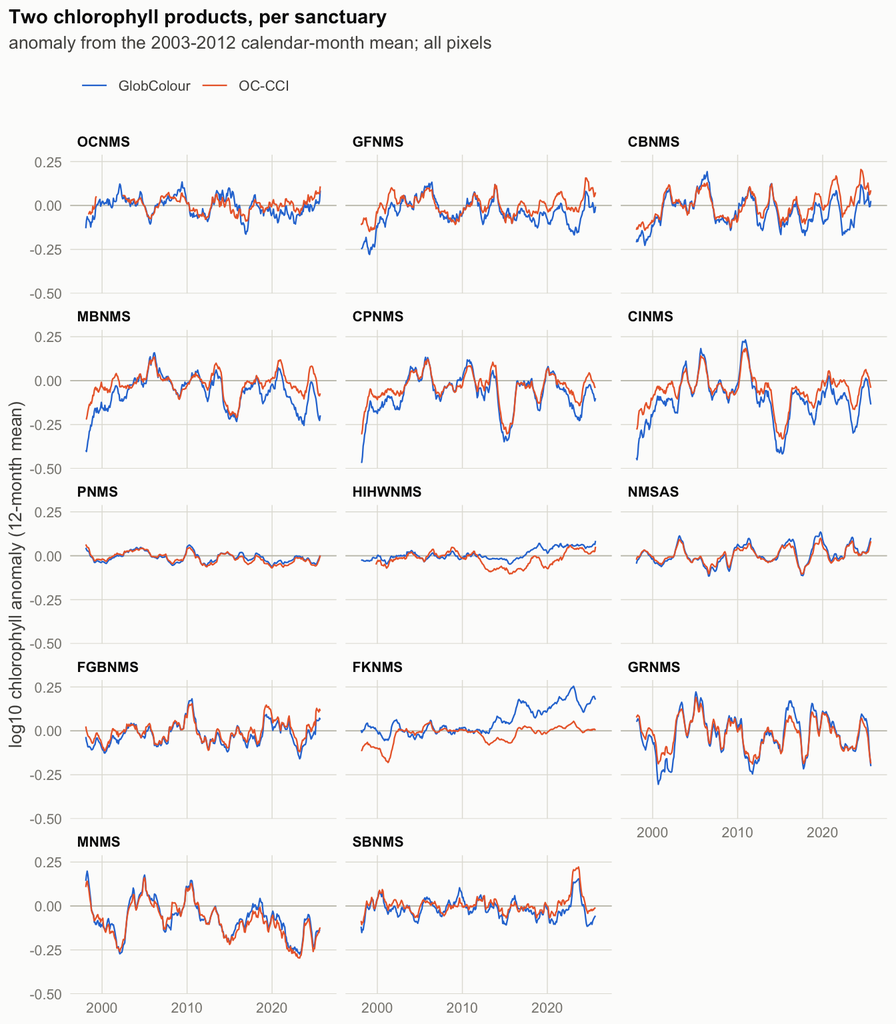

Figure 2

```r
p_cmp <- cmp_d |>
  mutate(nms = factor(nms, NMS_ORD)) |>
  arrange(nms, date) |>
  group_by(nms) |>
  mutate(
    `OC-CCI`         = rollapply(oc_a, 12, mean, fill = NA, align = "center"),
    `GlobColour`     = rollapply(gc_a, 12, mean, fill = NA, align = "center")) |>
  ungroup() |>
  pivot_longer(c(`OC-CCI`, GlobColour), names_to = "product", values_to = "anom") |>
  ggplot(aes(date, anom, color = product)) +
  geom_hline(yintercept = 0, color = PAL$axis, linewidth = 0.3) +
  geom_line(linewidth = 0.4, na.rm = T) +
  scale_color_manual(values = c("OC-CCI" = PAL$orange, GlobColour = PAL$blue), name = NULL) +
  facet_wrap(~nms, ncol = 3) +
  labs(x = NULL, y = "log10 chlorophyll anomaly (12-month mean)",
       title = "Two chlorophyll products, per sanctuary",
       subtitle = "anomaly from the 2003-2012 calendar-month mean; all pixels") +
  theme_chk()
save_fig(p_cmp, "chl_product_compare.png", 9, 8)
```

## Checks

```r
# indices
stopifnot(
  identical(names(idx), c("date", "index", "value")),
  all(day(idx$date) == 1), !anyNA(idx$value),
  all(c("oni", "pdo", "npgo", "nao", "amo", "natl_sst") %in% idx$index),
  min(idx$date) == as.Date("1990-01-01"),
  nrow(distinct(idx, date, index)) == nrow(idx),
  identical(names(src), c("index", "long_name", "url", "retrieved", "first", "last", "note")),
  !anyNA(src$retrieved), all(src$last >= as.Date("2025-01-01") | src$index %in% c("amo", "natl_sst")))

# occci
stopifnot(
  identical(names(occci), c("nms", "date", "chl_occci", "chl_occci_all", "n_cells", "n_cells_all", "rule")),
  setequal(occci$nms, NMS_ORD), all(day(occci$date) == 1),
  min(occci$date) == as.Date("1997-09-01"),
  max(occci$date) >= as.Date("2025-09-01"),
  nrow(distinct(occci, nms, date)) == nrow(occci),
  all(table(occci$nms) == n_distinct(occci$date)),
  all(occci$chl_occci > 0, na.rm = T))
stopifnot(setequal(compare$nms, intersect(NMS_ORD, gc$nms)), length(NMS_ORD) == 14, identical(names(compare)[1], "nms"))
cat("all checks passed\n")
```

```
all checks passed
```